# Problem Set 3

Bruk Esayas

11/02/2026

**GitHub repo:** https://github.com/00bruk/ec522_ps3_esayas

## 1. Time and Tsibbles

U.S. retail sales dataset (retail_ts) is sourced from FRED w/ monthly observations. The index is Month and the key is series_id to distinguish between the different series.

Canadian gas production dataset (can_gas) comes from the fpp3 package w/ monthly observations as well. It is a single time series and thus has no key, the index is Month.

```
## # A tsibble: 6 x 5 [1M]
##      Month Volume  year month quarter
##      <mth>  <dbl> <dbl> <ord>   <int>
## 1 1990 Jan   12.5  1990 Jan         1
## 2 1990 Feb   11.2  1990 Feb         1
## 3 1990 Mar   11.6  1990 Mar         1
## 4 1990 Apr   11.1  1990 Apr         2
## 5 1990 May   11.0  1990 May         2
## 6 1990 Jun   10.1  1990 Jun         2
```

Average Canadian Gas Production by Month (1990-2005)

| month | avg_volume |
| --- | --- |
| Jan | 16.99 |
| Feb | 15.28 |
| Mar | 16.34 |
| Apr | 15.74 |
| May | 15.75 |
| Jun | 14.94 |
| Jul | 15.60 |
| Aug | 15.62 |
| Sep | 15.13 |
| Oct | 16.16 |
| Nov | 16.18 |
| Dec | 17.15 |

```
## # A tsibble: 6 x 2 [1Q]
##   Quarter Volume
##     <qtr>  <dbl>
## 1 1960 Q1   4.14
## 2 1960 Q2   3.30
## 3 1960 Q3   2.97
## 4 1960 Q4   4.26
## 5 1961 Q1   5.01
## 6 1961 Q2   4.17
```

Calendar month production: Highest avg production month is December (17.1). Lowest is June (14.9).

Quarterly aggregation: We summed the monthly values instead of using the mean because the data shows total volume produced over that month, so quarterly production should represent the total volume produced over that quarter.

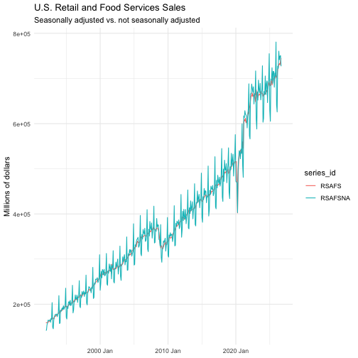

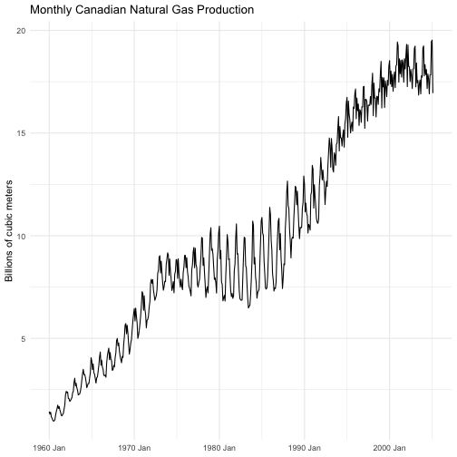

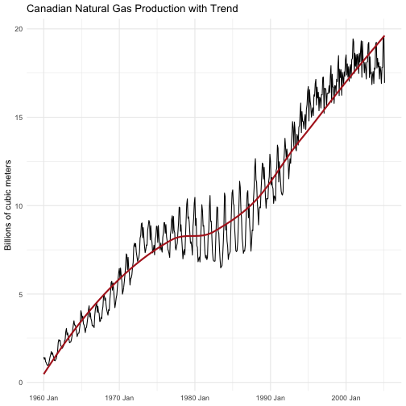

## 2. Transformations

Log Transformation: Seasonal swings in Canadian gas production grows with the level of the series. Using the natural loga of the data stabilizes this variance, making logs the most suitable transformation before modeling the data.

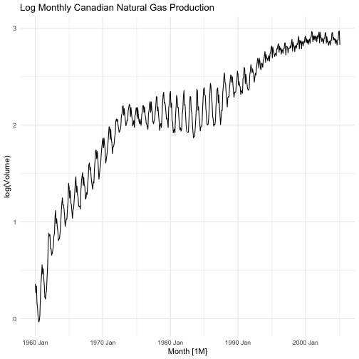

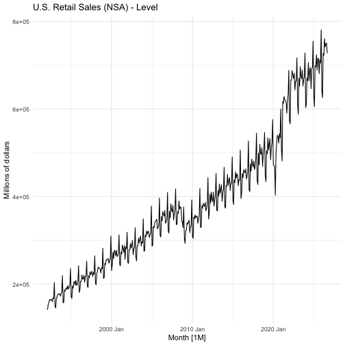

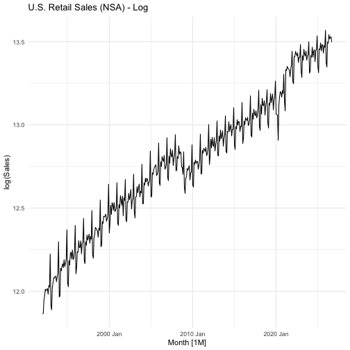

For the same reason, logging the U.S. retail sales data is also appropriate because the seasonal swings in the data grow with the level of the series.

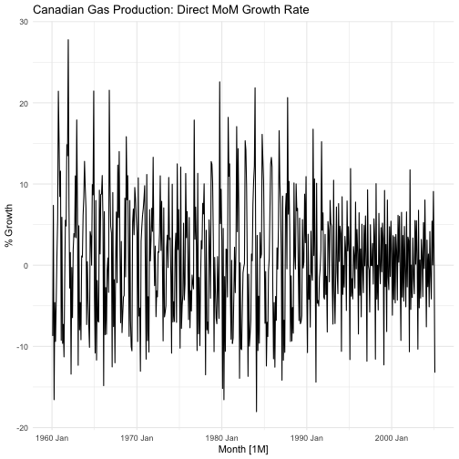

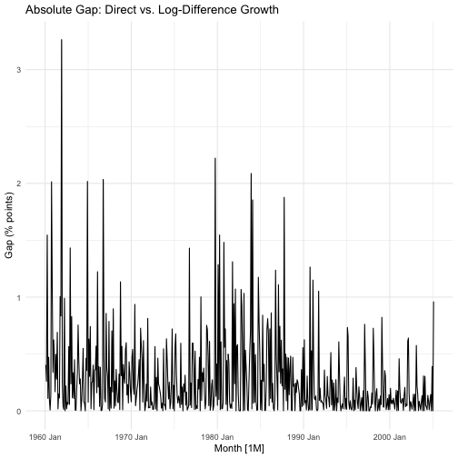

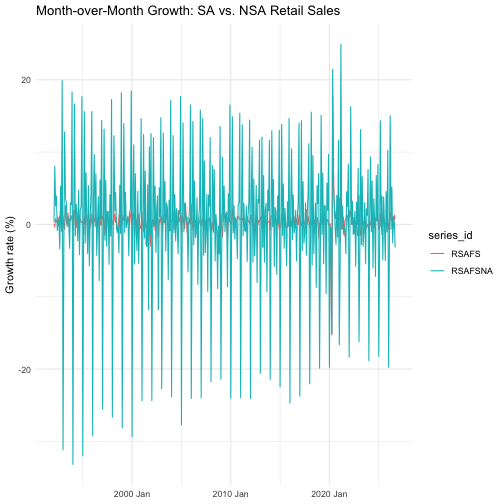

## 3. Seasonality

Seasonal Plots and Subseries:

Seasonally adjusted retail sales series (RSAFS) is smoother than the non-seasonally adjusted one (RSAFSNA). It visually demonstrates that seasonal adjustment successfully removes the calendar fluctuations.

Canadian natural gas production peaks quickly during the winter months (December through January) and dips during the summer (June through July). This shows the higher heating demand in colder months.

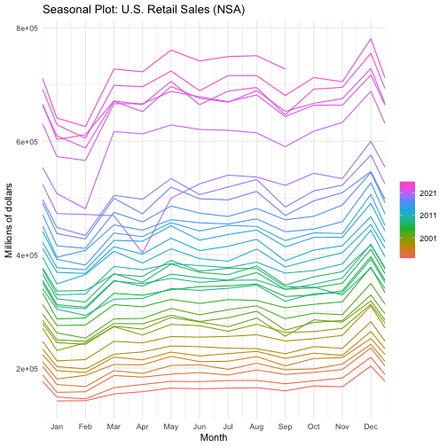

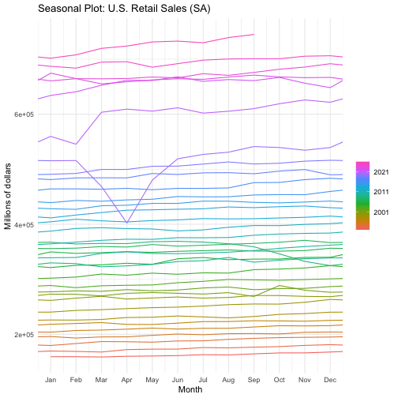

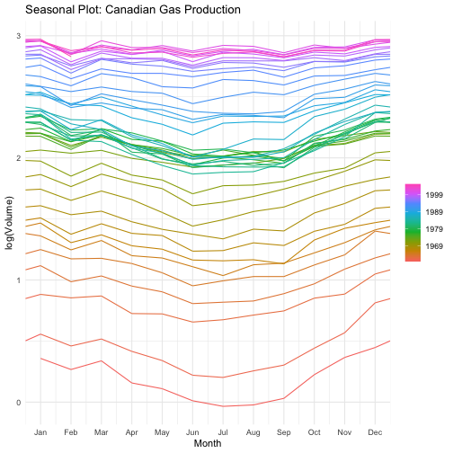

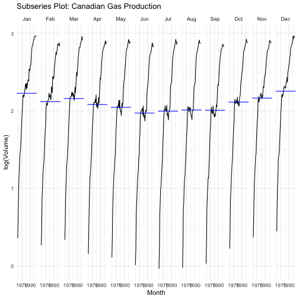

X-13ARIMA-SEATS & TSLM: Comparing the X-13 seasonal adjustment to the Census Bureau’s reported adjustment shows a pretty close match, with % differences fluctuating positively and negatively around zero.

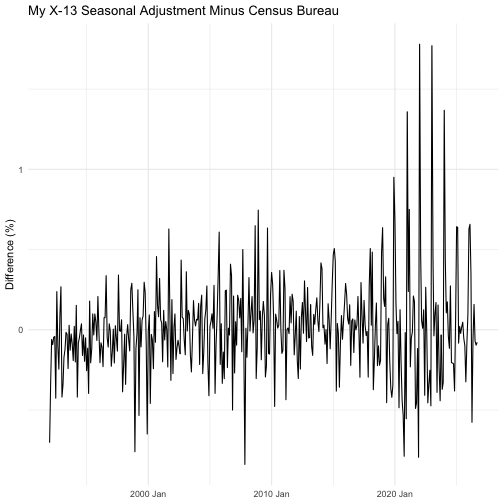

Linear Trend + Seasonal Dummies

| term | estimate | std.error | statistic | p.value |
| --- | --- | --- | --- | --- |
| (Intercept) | 1.150 | 0.041 | 27.761 | 0.000 |
| trend() | 0.004 | 0.000 | 57.692 | 0.000 |
| season()year2 | -0.112 | 0.052 | -2.144 | 0.032 |
| season()year3 | -0.052 | 0.053 | -0.996 | 0.320 |
| season()year4 | -0.133 | 0.053 | -2.537 | 0.011 |
| season()year5 | -0.174 | 0.053 | -3.305 | 0.001 |
| season()year6 | -0.251 | 0.053 | -4.777 | 0.000 |
| season()year7 | -0.230 | 0.053 | -4.374 | 0.000 |
| season()year8 | -0.219 | 0.053 | -4.170 | 0.000 |
| season()year9 | -0.227 | 0.053 | -4.325 | 0.000 |
| season()year10 | -0.125 | 0.053 | -2.383 | 0.018 |
| season()year11 | -0.078 | 0.053 | -1.480 | 0.140 |
| season()year12 | 0.007 | 0.053 | 0.137 | 0.891 |

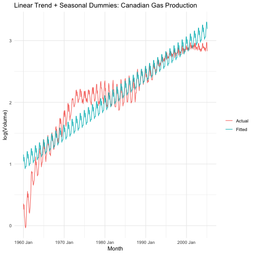

```
## # A tibble: 1 × 3
##   .model lb_stat lb_pvalue
##   <chr>    <dbl>     <dbl>
## 1 tslm     7774.         0
```

Ljung-Box Test: Residuals from the linear trend, seasonal dummies model returns a large test statistic and a p-value ~ 0, leading us to reject the null hypothesis of white noise. This implies that the model leaving behind large levels of autocorrelation.

## 4. Forecast Evaluation

*Expanding Window TS-CV:

Expanding Window TS-CV Accuracy

| .model | .type | MAE | RMSE |
| --- | --- | --- | --- |
| snaive | Test | 0.562 | 0.702 |
| tslm | Test | 4.009 | 4.362 |

Rolling Window TS-CV Accuracy

| .model | .type | MAE | RMSE |
| --- | --- | --- | --- |
| snaive | Test | 0.562 | 0.702 |
| tslm | Test | 2.095 | 2.425 |

## 5. Reflection

Residuals from our TSLM are not simply white noise. There is some strong autocorrelation left in the residuals (as proven by the Ljung-Box test). This reveals that the model is not purely capturing all the patterns of the data. For a future improvement, maybe we could try to do some ARIMA modeling on the residuals in hopes of capturing the remaining autocorrelation.